# Data transformation

Hans

4/13/2021

```
##     Ozone Solar.R Wind Temp Month Day
## 1      41     190  7.4   67     5   1
## 2      36     118  8.0   72     5   2
## 3      12     149 12.6   74     5   3
## 4      18     313 11.5   62     5   4
## 5      NA      NA 14.3   56     5   5
## 6      28      NA 14.9   66     5   6
## 7      23     299  8.6   65     5   7
## 8      19      99 13.8   59     5   8
## 9       8      19 20.1   61     5   9
## 10     NA     194  8.6   69     5  10
## 11      7      NA  6.9   74     5  11
## 12     16     256  9.7   69     5  12
## 13     11     290  9.2   66     5  13
## 14     14     274 10.9   68     5  14
```

[output cut: 139 more lines]

#dealing with missing values #1:Omit

```
##     Ozone Solar.R Wind Temp Month Day
## 1      41     190  7.4   67     5   1
## 2      36     118  8.0   72     5   2
## 3      12     149 12.6   74     5   3
## 4      18     313 11.5   62     5   4
## 7      23     299  8.6   65     5   7
## 8      19      99 13.8   59     5   8
## 9       8      19 20.1   61     5   9
## 12     16     256  9.7   69     5  12
## 13     11     290  9.2   66     5  13
## 14     14     274 10.9   68     5  14
## 15     18      65 13.2   58     5  15
## 16     14     334 11.5   64     5  16
## 17     34     307 12.0   66     5  17
## 18      6      78 18.4   57     5  18
```

[output cut: 97 more lines]

#2:Replacing missing values with mean

```
##         Ozone Solar.R Wind Temp Month Day
## 1    41.00000     190  7.4   67     5   1
## 2    36.00000     118  8.0   72     5   2
## 3    12.00000     149 12.6   74     5   3
## 4    18.00000     313 11.5   62     5   4
## 5    42.12931      NA 14.3   56     5   5
## 6    28.00000      NA 14.9   66     5   6
## 7    23.00000     299  8.6   65     5   7
## 8    19.00000      99 13.8   59     5   8
## 9     8.00000      19 20.1   61     5   9
## 10   42.12931     194  8.6   69     5  10
## 11    7.00000      NA  6.9   74     5  11
## 12   16.00000     256  9.7   69     5  12
## 13   11.00000     290  9.2   66     5  13
## 14   14.00000     274 10.9   68     5  14
```

[output cut: 139 more lines]

```
##      Ozone Solar.R Wind Temp Month Day
## 1    41.00     190  7.4   67     5   1
## 2    36.00     118  8.0   72     5   2
## 3    12.00     149 12.6   74     5   3
## 4    18.00     313 11.5   62     5   4
## 5    42.13      NA 14.3   56     5   5
## 6    28.00      NA 14.9   66     5   6
## 7    23.00     299  8.6   65     5   7
## 8    19.00      99 13.8   59     5   8
## 9     8.00      19 20.1   61     5   9
## 10   42.13     194  8.6   69     5  10
## 11    7.00      NA  6.9   74     5  11
## 12   16.00     256  9.7   69     5  12
## 13   11.00     290  9.2   66     5  13
## 14   14.00     274 10.9   68     5  14
```

[output cut: 139 more lines]

```
##      Ozone Solar.R Wind Temp Month Day
## 1    41.00  190.00  7.4   67     5   1
## 2    36.00  118.00  8.0   72     5   2
## 3    12.00  149.00 12.6   74     5   3
## 4    18.00  313.00 11.5   62     5   4
## 5    42.13  185.93 14.3   56     5   5
## 6    28.00  185.93 14.9   66     5   6
## 7    23.00  299.00  8.6   65     5   7
## 8    19.00   99.00 13.8   59     5   8
## 9     8.00   19.00 20.1   61     5   9
## 10   42.13  194.00  8.6   69     5  10
## 11    7.00  185.93  6.9   74     5  11
## 12   16.00  256.00  9.7   69     5  12
## 13   11.00  290.00  9.2   66     5  13
## 14   14.00  274.00 10.9   68     5  14
```

[output cut: 139 more lines]

```
##      Ozone Solar.R Wind Temp Month Day
## 1    41.00  190.00  7.4   67     5   1
## 2    36.00  118.00  8.0   72     5   2
## 3    12.00  149.00 12.6   74     5   3
## 4    18.00  313.00 11.5   62     5   4
## 5    42.13  185.93 14.3   56     5   5
## 6    28.00  185.93 14.9   66     5   6
## 7    23.00  299.00  8.6   65     5   7
## 8    19.00   99.00 13.8   59     5   8
## 9     8.00   19.00 20.1   61     5   9
## 10   42.13  194.00  8.6   69     5  10
## 11    7.00  185.93  6.9   74     5  11
## 12   16.00  256.00  9.7   69     5  12
## 13   11.00  290.00  9.2   66     5  13
## 14   14.00  274.00 10.9   68     5  14
```

[output cut: 139 more lines]

**Plots** #1:Barchart

```
##   Ozone Solar.R Wind Temp Month Day
## 1 41.00  190.00  7.4   67     5   1
## 2 36.00  118.00  8.0   72     5   2
## 3 12.00  149.00 12.6   74     5   3
## 4 18.00  313.00 11.5   62     5   4
## 5 42.13  185.93 14.3   56     5   5
## 6 28.00  185.93 14.9   66     5   6
```

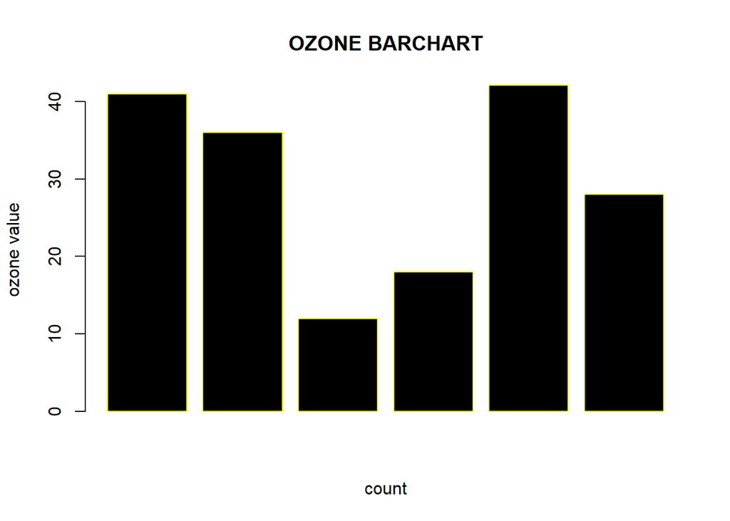

#Adding legend to chart?

#code eg. #legend(“topleft”,regions,cex=1.3,fill=(“green”,“pink”))

**Pie chart** #code #pie(x,labels,radius,main,col,clockwise) #x-vector that contains numeric value used in pie chart #labels-used to give description to slices #radius-? #Main-title #Cot-colour of the palette #clockwise-logical value that indicates the clockwise or anti-clockwise direction in whuch slices are drawn

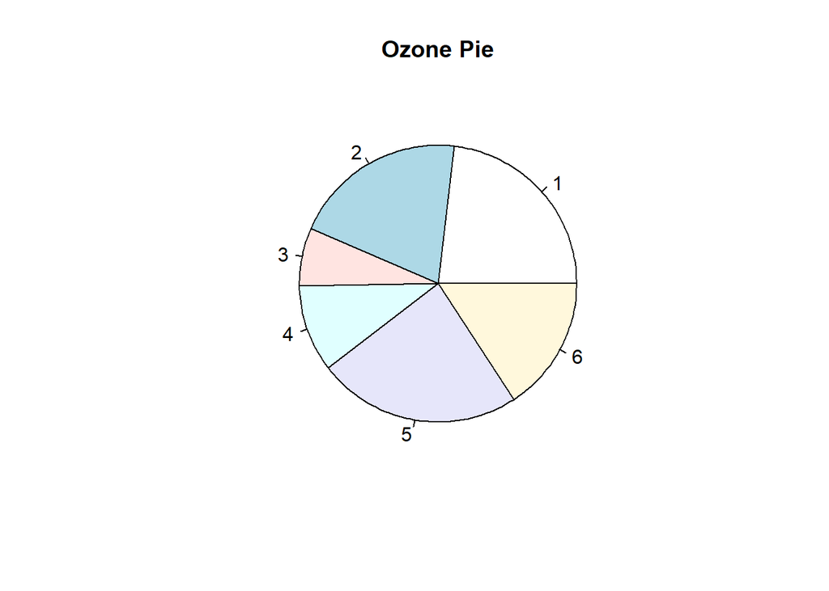

#Adding title to pie chart

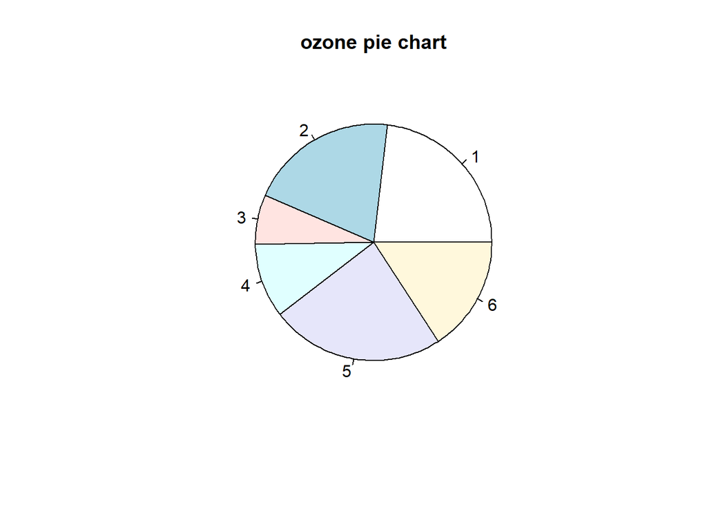

#3:**Boxplot** #measure of how data is distributed in a data set #boxplot(x,data,notch,varwidth,names,main) #x-vector or formula #data-data frame #Notch-logical value set as true to draw a notch #varwidth-logical value set as true to draw width of box same as sample size. #names-is a group of labels that will be printed under each boxplot #main-title

```
##                      mpg cyl  disp  hp drat    wt  qsec vs am gear carb
## Mazda RX4           21.0   6 160.0 110 3.90 2.620 16.46  0  1    4    4
## Mazda RX4 Wag       21.0   6 160.0 110 3.90 2.875 17.02  0  1    4    4
## Datsun 710          22.8   4 108.0  93 3.85 2.320 18.61  1  1    4    1
## Hornet 4 Drive      21.4   6 258.0 110 3.08 3.215 19.44  1  0    3    1
## Hornet Sportabout   18.7   8 360.0 175 3.15 3.440 17.02  0  0    3    2
## Valiant             18.1   6 225.0 105 2.76 3.460 20.22  1  0    3    1
## Duster 360          14.3   8 360.0 245 3.21 3.570 15.84  0  0    3    4
## Merc 240D           24.4   4 146.7  62 3.69 3.190 20.00  1  0    4    2
## Merc 230            22.8   4 140.8  95 3.92 3.150 22.90  1  0    4    2
## Merc 280            19.2   6 167.6 123 3.92 3.440 18.30  1  0    4    4
## Merc 280C           17.8   6 167.6 123 3.92 3.440 18.90  1  0    4    4
## Merc 450SE          16.4   8 275.8 180 3.07 4.070 17.40  0  0    3    3
## Merc 450SL          17.3   8 275.8 180 3.07 3.730 17.60  0  0    3    3
## Merc 450SLC         15.2   8 275.8 180 3.07 3.780 18.00  0  0    3    3
## Cadillac Fleetwood  10.4   8 472.0 205 2.93 5.250 17.98  0  0    3    4
## Lincoln Continental 10.4   8 460.0 215 3.00 5.424 17.82  0  0    3    4
## Chrysler Imperial   14.7   8 440.0 230 3.23 5.345 17.42  0  0    3    4
## Fiat 128            32.4   4  78.7  66 4.08 2.200 19.47  1  1    4    1
## Honda Civic         30.4   4  75.7  52 4.93 1.615 18.52  1  1    4    2
## Toyota Corolla      33.9   4  71.1  65 4.22 1.835 19.90  1  1    4    1
## Toyota Corona       21.5   4 120.1  97 3.70 2.465 20.01  1  0    3    1
## Dodge Challenger    15.5   8 318.0 150 2.76 3.520 16.87  0  0    3    2
## AMC Javelin         15.2   8 304.0 150 3.15 3.435 17.30  0  0    3    2
## Camaro Z28          13.3   8 350.0 245 3.73 3.840 15.41  0  0    3    4
## Pontiac Firebird    19.2   8 400.0 175 3.08 3.845 17.05  0  0    3    2
## Fiat X1-9           27.3   4  79.0  66 4.08 1.935 18.90  1  1    4    1
## Porsche 914-2       26.0   4 120.3  91 4.43 2.140 16.70  0  1    5    2
## Lotus Europa        30.4   4  95.1 113 3.77 1.513 16.90  1  1    5    2
## Ford Pantera L      15.8   8 351.0 264 4.22 3.170 14.50  0  1    5    4
## Ferrari Dino        19.7   6 145.0 175 3.62 2.770 15.50  0  1    5    6
## Maserati Bora       15.0   8 301.0 335 3.54 3.570 14.60  0  1    5    8
## Volvo 142E          21.4   4 121.0 109 4.11 2.780 18.60  1  1    4    2
```

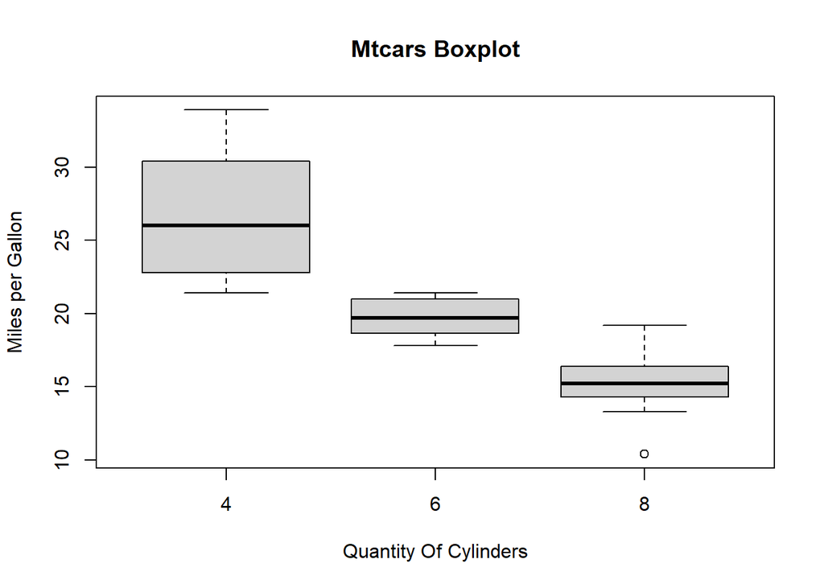

#Boxplot using Notch-helps find out how medians of different data groups match with each other.

#NB:Colour not applied below

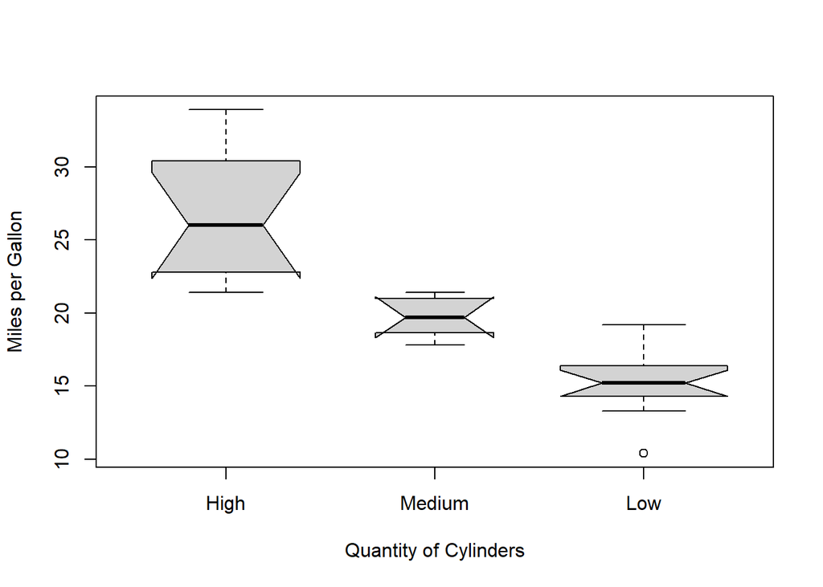

#3:**Line Graph** #Is a pictorial representation of information which changes over time. #plot(v,type,col,xlb,ylab) #v -vector containing numeric values #type-this parameter takes only values ?l?to draw only line or?p? to draw the points and“o” to draw both point and line

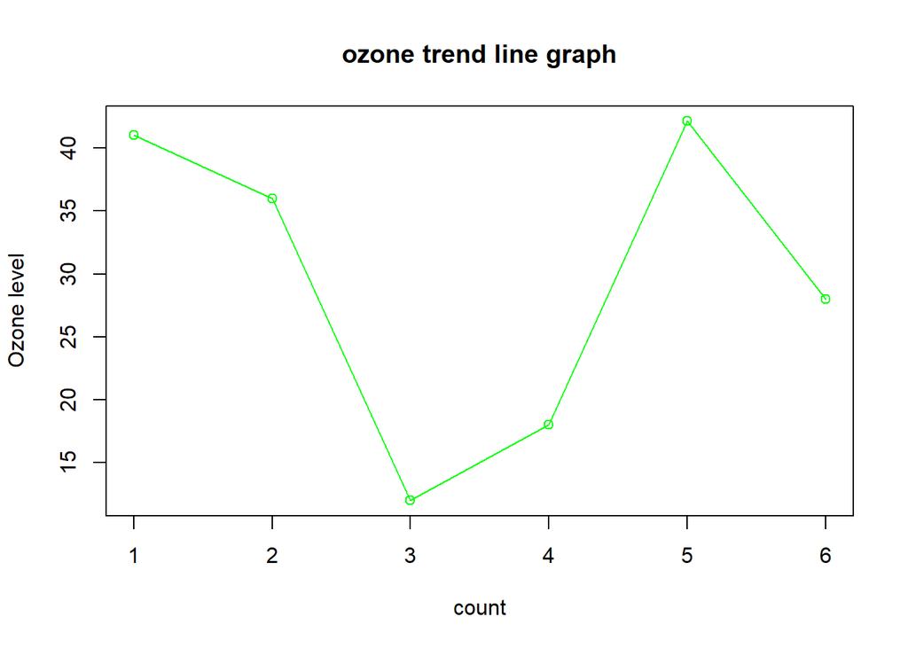

#4:**Scatter plot** #used to compare variables #each point on the scatter plot defines value of two variables

#plot(x,y,main,xlab,ylab,xlim,ylim,axes) #x- data set whose values are on the horizontal axis #y-? #main-? #xlab-label of horizontal axis #ylab-? #xlim-limit of x values which are used for plotting #ylim-? #axes-indicates if both axes should be drawn on the plot.

```
##                        wt  mpg
## Mazda RX4           2.620 21.0
## Mazda RX4 Wag       2.875 21.0
## Datsun 710          2.320 22.8
## Hornet 4 Drive      3.215 21.4
## Hornet Sportabout   3.440 18.7
## Valiant             3.460 18.1
## Duster 360          3.570 14.3
## Merc 240D           3.190 24.4
## Merc 230            3.150 22.8
## Merc 280            3.440 19.2
## Merc 280C           3.440 17.8
## Merc 450SE          4.070 16.4
## Merc 450SL          3.730 17.3
## Merc 450SLC         3.780 15.2
## Cadillac Fleetwood  5.250 10.4
## Lincoln Continental 5.424 10.4
## Chrysler Imperial   5.345 14.7
## Fiat 128            2.200 32.4
## Honda Civic         1.615 30.4
## Toyota Corolla      1.835 33.9
## Toyota Corona       2.465 21.5
## Dodge Challenger    3.520 15.5
## AMC Javelin         3.435 15.2
## Camaro Z28          3.840 13.3
## Pontiac Firebird    3.845 19.2
## Fiat X1-9           1.935 27.3
## Porsche 914-2       2.140 26.0
## Lotus Europa        1.513 30.4
## Ford Pantera L      3.170 15.8
## Ferrari Dino        2.770 19.7
## Maserati Bora       3.570 15.0
## Volvo 142E          2.780 21.4
```

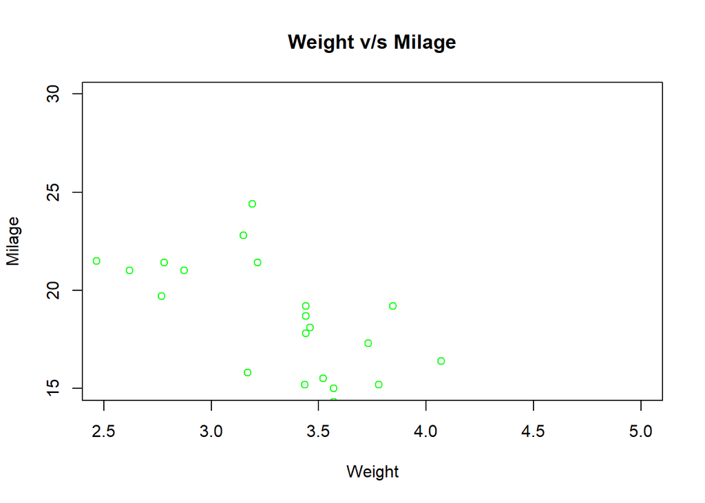